# Midway Mock Exam Solution

[**CCMVI2085U Machine Learning for Predictive Analytics in Business @ CBS ISUP 2020**](https://kursuskatalog.cbs.dk/2019-2020/KAN-CCMVI2085U.aspx?lang=en-GB)

Course coordinator: [Bowei Chen](https://boweichen.github.io/) | Email: bc.acc@cbs.dk

### Section 1 (15%)

Download "customer_churn.csv" dataset, and insert your Python codes below to:

1. Read the dataset into a data frame and name it `df` (1%)
2. Show the last 10 observations of `df` (2%)
3. Delete the column `User_ID` from `df` (2%)
4. Show the shape of `df` (2%)
5. Show the data types of each column in df and convert the object columns to categorical variables (5%)
6. Summarise the numerical variables in df (e.g., number of observations, mean, standard deviations, min value, max value, etc.) and check if the numerical variables are linearly correlated (3%)

#### Solution to Q1

```python
import numpy as np
import pandas as pd
import matplotlib.pyplot as plt
import seaborn as sns

sns.set_style("whitegrid")
%matplotlib inline
%load_ext nb_black
```

```python
df = pd.read_csv("customer_churn.csv")
```

#### Solution to Q2

```python
df.tail(n=10)
```

|  | User_ID | User_Gender | Is_Senior | Has_Partner | Has_Children | Usage_Length | Has_Phone_Service | Multiple_Lines | Intnet_Provider | Has_Security_Service | Has_Online_Backup | Has_Device_Protection | Has_Tech_Support | Has_Steam_TV | Has_Steam_Movies | Contract_Type | Has_Paperless_Billing | Payment_Method | Monthly_Fee | Attrition |
| --- | --- | --- | --- | --- | --- | --- | --- | --- | --- | --- | --- | --- | --- | --- | --- | --- | --- | --- | --- | --- |
| 690 | 690 | F | No | Yes | Yes | 72 | Yes | Yes | DSL | No | No | Yes | No | Yes | No | Two year | Yes | Bank transfer (automatic) | 51.20 | No |
| 691 | 691 | M | No | Yes | No | 23 | Yes | Yes | Fiber optic | No | Yes | Yes | No | No | No | Month-to-month | No | Electronic check | 56.17 | No |
| 692 | 692 | F | No | Yes | No | 37 | Yes | No | No | No internet service | No internet service | No internet service | No internet service | No internet service | No | Month-to-month | No | Bank transfer (automatic) | 13.00 | No |
| 693 | 693 | M | No | No | No | 20 | Yes | Yes | DSL | No | Yes | No | Yes | Yes | No | One year | Yes | Electronic check | 45.80 | No |
| 694 | 694 | M | No | Yes | No | 66 | Yes | Yes | Fiber optic | No | Yes | Yes | No | No | No | One year | No | Electronic check | 63.53 | No |
| 695 | 695 | M | No | Yes | Yes | 57 | Yes | No | DSL | Yes | Yes | No | Yes | No | No | One year | No | Mailed check | 39.73 | No |
| 696 | 696 | M | No | Yes | No | 54 | Yes | No | Fiber optic | Yes | Yes | Yes | Yes | Yes | No | Two year | No | Bank transfer (automatic) | 73.17 | Yes |
| 697 | 697 | M | No | No | No | 27 | Yes | No | No | No internet service | No internet service | No internet service | No internet service | No internet service | No | Two year | No | Credit card (automatic) | 13.23 | No |
| 698 | 698 | F | No | No | No | 67 | Yes | Yes | Fiber optic | Yes | Yes | Yes | No | Yes | No | Month-to-month | Yes | Credit card (automatic) | 68.63 | Yes |
| 699 | 699 | M | No | No | No | 20 | Yes | Yes | Fiber optic | No | No | No | No | Yes | No | Month-to-month | Yes | Electronic check | 56.83 | Yes |

#### Solution to Q3

```python
del df["User_ID"]
df.columns
```

```
Index(['User_Gender', 'Is_Senior', 'Has_Partner', 'Has_Children',
       'Usage_Length', 'Has_Phone_Service', 'Multiple_Lines',
       'Intnet_Provider', 'Has_Security_Service', 'Has_Online_Backup',
       'Has_Device_Protection', 'Has_Tech_Support', 'Has_Steam_TV',
       'Has_Steam_Movies', 'Contract_Type', 'Has_Paperless_Billing',
       'Payment_Method', 'Monthly_Fee', 'Attrition'],
      dtype='object')
```

#### Solution to Q4

```python
df.shape
```

```
(700, 19)
```

#### Solution to Q5

```python
df.dtypes
```

```
User_Gender               object
Is_Senior                 object
Has_Partner               object
Has_Children              object
Usage_Length               int64
Has_Phone_Service         object
Multiple_Lines            object
Intnet_Provider           object
Has_Security_Service      object
Has_Online_Backup         object
Has_Device_Protection     object
Has_Tech_Support          object
Has_Steam_TV              object
Has_Steam_Movies          object
Contract_Type             object
Has_Paperless_Billing     object
Payment_Method            object
Monthly_Fee              float64
Attrition                 object
dtype: object
```

```python
df[df.select_dtypes(include="object").columns] = df.select_dtypes(
    include="object"
).astype("category")
df.dtypes
```

```
User_Gender              category
Is_Senior                category
Has_Partner              category
Has_Children             category
Usage_Length                int64
Has_Phone_Service        category
Multiple_Lines           category
Intnet_Provider          category
Has_Security_Service     category
Has_Online_Backup        category
Has_Device_Protection    category
Has_Tech_Support         category
Has_Steam_TV             category
Has_Steam_Movies         category
Contract_Type            category
Has_Paperless_Billing    category
Payment_Method           category
Monthly_Fee               float64
Attrition                category
dtype: object
```

#### Solution to Q6

```python
df.describe()
```

|  | Usage_Length | Monthly_Fee |
| --- | --- | --- |
| count | 700.000000 | 700.000000 |
| mean | 34.117143 | 42.817771 |
| std | 25.329768 | 20.472124 |
| min | 0.000000 | 12.500000 |
| 25% | 10.000000 | 20.110000 |
| 50% | 32.000000 | 46.850000 |
| 75% | 60.000000 | 59.772500 |
| max | 72.000000 | 78.400000 |

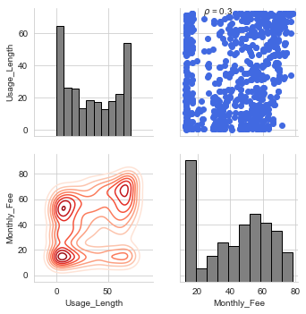

```python
import seaborn as sns
import matplotlib.pyplot as plt

# Function to calculate correlation coefficient between two arrays
def corr(x, y, **kwargs):

    # Calculate the value
    coef = np.corrcoef(x, y)[0][1]
    # Make the label
    label = r"$\rho$ = " + str(round(coef, 2))

    # Add the label to the plot
    ax = plt.gca()
    ax.annotate(label, xy=(0.2, 0.95), size=10, xycoords=ax.transAxes)


# Create an instance of the PairGrid class.
grid = sns.PairGrid(
    data=df, vars=df.select_dtypes(include=["int64", "float64"]).columns
)

# Map a scatter plot to the upper triangle
grid = grid.map_upper(plt.scatter, color="RoyalBlue")
grid = grid.map_upper(corr)

# Map a histogram to the diagonal
grid = grid.map_diag(plt.hist, bins=10, color="Gray", edgecolor="k")

# Map a density plot to the lower triangle
grid = grid.map_lower(sns.kdeplot, cmap="Reds")
```

### Section 2 (15%)

Insert your Python codes below to conduct the following data pre-processing operations:

1. Create another data frame `df2` which is a copy of df (2%)
2. Encode the categorical columns of `df2` into binary variables (5%)
3. Create a dictionary and name it `cc`. The dictionary has two keys: 'data' and 'target', and the corresponding key values are NumPy arrays. For 'target', the key value is an array of values from column 'Attrition' of `df2`. For 'data', the key value is an array whose sub arrays of all other columns of `df2`. Each sub array is an observation of all other columns of `df2`. (8%)

#### Solution to Q1

```python
df2 = df.copy()
```

#### Solution to Q2

```python
df2 = pd.get_dummies(df.select_dtypes(include="category"), drop_first=True)
df2.head()
```

|  | User_Gender_M | Is_Senior_Yes | Has_Partner_Yes | Has_Children_Yes | Has_Phone_Service_Yes | Multiple_Lines_No phone service | Multiple_Lines_Yes | Intnet_Provider_Fiber optic | Intnet_Provider_No | Has_Security_Service_No internet service | ... | Has_Tech_Support_Yes | Has_Steam_TV_No internet service | Has_Steam_TV_Yes | Contract_Type_One year | Contract_Type_Two year | Has_Paperless_Billing_Yes | Payment_Method_Credit card (automatic) | Payment_Method_Electronic check | Payment_Method_Mailed check | Attrition_Yes |
| --- | --- | --- | --- | --- | --- | --- | --- | --- | --- | --- | --- | --- | --- | --- | --- | --- | --- | --- | --- | --- | --- |
| 0 | 1 | 0 | 0 | 0 | 1 | 0 | 0 | 1 | 0 | 0 | ... | 0 | 0 | 1 | 0 | 0 | 0 | 0 | 1 | 0 | 1 |
| 1 | 0 | 0 | 1 | 0 | 1 | 0 | 1 | 0 | 0 | 0 | ... | 1 | 0 | 1 | 1 | 0 | 1 | 1 | 0 | 0 | 0 |
| 2 | 0 | 0 | 1 | 0 | 1 | 0 | 0 | 0 | 1 | 1 | ... | 0 | 1 | 0 | 0 | 1 | 0 | 0 | 0 | 1 | 0 |
| 3 | 1 | 0 | 0 | 0 | 1 | 0 | 0 | 0 | 0 | 0 | ... | 0 | 0 | 0 | 0 | 0 | 1 | 0 | 0 | 1 | 1 |
| 4 | 1 | 1 | 0 | 0 | 1 | 0 | 0 | 1 | 0 | 0 | ... | 0 | 0 | 1 | 0 | 0 | 1 | 0 | 1 | 0 | 1 |

5 rows × 26 columns

```python
df_final_pd = pd.concat(
    [df.select_dtypes(include=["int64", "float64"]), df2], axis=1, ignore_index=False
)
df_final_pd.head()
```

|  | Usage_Length | Monthly_Fee | User_Gender_M | Is_Senior_Yes | Has_Partner_Yes | Has_Children_Yes | Has_Phone_Service_Yes | Multiple_Lines_No phone service | Multiple_Lines_Yes | Intnet_Provider_Fiber optic | ... | Has_Tech_Support_Yes | Has_Steam_TV_No internet service | Has_Steam_TV_Yes | Contract_Type_One year | Contract_Type_Two year | Has_Paperless_Billing_Yes | Payment_Method_Credit card (automatic) | Payment_Method_Electronic check | Payment_Method_Mailed check | Attrition_Yes |
| --- | --- | --- | --- | --- | --- | --- | --- | --- | --- | --- | --- | --- | --- | --- | --- | --- | --- | --- | --- | --- | --- |
| 0 | 2 | 63.77 | 1 | 0 | 0 | 0 | 1 | 0 | 0 | 1 | ... | 0 | 0 | 1 | 0 | 0 | 0 | 0 | 1 | 0 | 1 |
| 1 | 26 | 60.07 | 0 | 0 | 1 | 0 | 1 | 0 | 1 | 0 | ... | 1 | 0 | 1 | 1 | 0 | 1 | 1 | 0 | 0 | 0 |
| 2 | 18 | 13.40 | 0 | 0 | 1 | 0 | 1 | 0 | 0 | 0 | ... | 0 | 1 | 0 | 0 | 1 | 0 | 0 | 0 | 1 | 0 |
| 3 | 7 | 34.00 | 1 | 0 | 0 | 0 | 1 | 0 | 0 | 0 | ... | 0 | 0 | 0 | 0 | 0 | 1 | 0 | 0 | 1 | 1 |
| 4 | 5 | 59.67 | 1 | 1 | 0 | 0 | 1 | 0 | 0 | 1 | ... | 0 | 0 | 1 | 0 | 0 | 1 | 0 | 1 | 0 | 1 |

5 rows × 28 columns

#### Solution to Q3

```python
cc = {
    "data": df_final_pd.iloc[:, :-1].to_numpy(),
    "target": df_final_pd["Attrition_Yes"].to_numpy(),
}
cc
```

```
{'data': array([[ 2.  , 63.77,  1.  , ...,  0.  ,  1.  ,  0.  ],
        [26.  , 60.07,  0.  , ...,  1.  ,  0.  ,  0.  ],
        [18.  , 13.4 ,  0.  , ...,  0.  ,  0.  ,  1.  ],
        ...,
        [27.  , 13.23,  1.  , ...,  1.  ,  0.  ,  0.  ],
        [67.  , 68.63,  0.  , ...,  1.  ,  0.  ,  0.  ],
        [20.  , 56.83,  1.  , ...,  0.  ,  1.  ,  0.  ]]),
 'target': array([1, 0, 0, 1, 1, 0, 0, 0, 0, 1, 0, 1, 0, 0, 0, 1, 0, 0, 0, 0, 0, 0,
        1, 0, 0, 0, 0, 0, 0, 0, 0, 0, 0, 0, 1, 0, 0, 1, 0, 0, 0, 1, 1, 0,
        1, 0, 1, 0, 0, 0, 0, 1, 0, 0, 0, 1, 1, 0, 0, 0, 0, 0, 0, 0, 0, 0,
        0, 0, 0, 0, 0, 1, 1, 0, 0, 0, 0, 0, 0, 0, 0, 0, 1, 0, 0, 0, 0, 0,
        0, 1, 0, 1, 1, 0, 0, 0, 0, 0, 0, 0, 0, 1, 1, 0, 0, 1, 0, 0, 1, 1,
        0, 0, 0, 0, 0, 1, 0, 0, 0, 0, 0, 0, 0, 1, 0, 0, 1, 1, 0, 1, 0, 0,
        0, 1, 0, 0, 0, 0, 0, 0, 0, 0, 0, 0, 0, 0, 1, 0, 1, 0, 0, 1, 0, 0,
        0, 0, 0, 0, 0, 0, 1, 0, 0, 0, 0, 0, 0, 0, 1, 0, 0, 1, 0, 1, 1, 0,
```

[output cut: 24 more lines]

### Section 3 (70%)

Insert your Python codes below to:

1. Split the data (the first 80% samples for training and the rest 20% samples for testing) (5%)
2. Explain how logistic regression and artificial neural network can be used to predict customer churn (i.e., the target variable is Attrition). (10%)
3. Train both models using the training data and make predictions using testing data. You can either write your own functions or use third-party libraries such as `sklearn` to train and test your models. Use your allocated random seed if applicable. (15%)
4. Report the model performance in the test set by:
   - Calculating (macro) accuracy, recall, precision. (10%)
   - Draw a grouped bar chart of the above metrics. (10%)
   - Draw a ROC/AUC graph of both models. (10%)
5. Discuss what you can further do to improve your models performance (500 words maximum) (10%)

#### Solution to Q1

```python
from sklearn.model_selection import train_test_split

x_train, x_test, y_train, y_test = train_test_split(
    cc["data"], cc["target"], test_size=0.2, shuffle=False
)
```

#### Solution to Q2

I do not provide solution to this question. You should write your understanding of both models using markdown in Jupyter notebook

#### Solution to Q3

```python
rand_seed = 100
```

```python
from sklearn.linear_model import LogisticRegression

lg = LogisticRegression(
    random_state=rand_seed, solver="newton-cg", multi_class="multinomial"
)
lg.fit(x_train, y_train)
y_pred_label_test_lg = lg.predict(x_test)
y_pred_label_prob_test_lg = lg.predict_proba(x_test)[:, 1]
```

```python
from sklearn.neural_network import MLPClassifier

mlp = MLPClassifier(
    max_iter=5000, alpha=1e-5, random_state=rand_seed, learning_rate="adaptive"
)
mlp.fit(x_train, y_train)
y_pred_label_test_mlp = mlp.predict(x_test)
y_pred_label_prob_test_mlp = mlp.predict_proba(x_test)[:, 1]
```

```python
df_pred_test = pd.DataFrame(
    data=[
        y_pred_label_test_lg,
        y_pred_label_prob_test_lg,
        y_pred_label_test_mlp,
        y_pred_label_prob_test_mlp,
    ]
)
df_pred_test = df_pred_test.T
df_pred_test.columns = [
    "LG_Pred",
    "LG_Pred_Prob",
    "MLP_Pred",
    "MLP_Pred_Prob",
]
df_pred_test.head()
```

|  | LG_Pred | LG_Pred_Prob | MLP_Pred | MLP_Pred_Prob |
| --- | --- | --- | --- | --- |
| 0 | 1.0 | 0.602918 | 1.0 | 0.647068 |
| 1 | 0.0 | 0.007820 | 0.0 | 0.000736 |
| 2 | 0.0 | 0.404635 | 0.0 | 0.188426 |
| 3 | 1.0 | 0.721424 | 1.0 | 0.898570 |
| 4 | 0.0 | 0.123241 | 0.0 | 0.077016 |

#### Solution to Q4

```python
from sklearn.metrics import recall_score
from sklearn.metrics import precision_score

met_accuracy = np.array([lg.score(x_test, y_test), mlp.score(x_test, y_test),])

met_recall = np.array(
    [
        recall_score(y_test, df_pred_test["LG_Pred"], average="macro"),
        recall_score(y_test, df_pred_test["MLP_Pred"], average="macro"),
    ]
)

met_precision = np.array(
    [
        precision_score(y_test, df_pred_test["LG_Pred"], average="macro"),
        precision_score(y_test, df_pred_test["MLP_Pred"], average="macro"),
    ]
)

df_performance = pd.DataFrame([met_accuracy, met_recall, met_precision])
df_performance = df_performance.T
df_performance.columns = ["Accuracy", "Recall", "Precision"]
df_performance.index = ["LG", "MLP"]
df_performance.head()
```

|  | Accuracy | Recall | Precision |
| --- | --- | --- | --- |
| LG | 0.8 | 0.674679 | 0.751926 |
| MLP | 0.8 | 0.683761 | 0.747126 |

```python
df_performance = df_performance.T
df_performance.head()
```

|  | LG | MLP |
| --- | --- | --- |
| Accuracy | 0.800000 | 0.800000 |
| Recall | 0.674679 | 0.683761 |
| Precision | 0.751926 | 0.747126 |

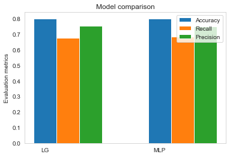

```python
fig, ax = plt.subplots()

width = 0.2  # the width of the bars
labels = df_performance.columns
x = np.arange(len(labels))  # the label locations

ax.bar(x, df_performance.iloc[0, :], width, label="Accuracy")
ax.bar(x + width, df_performance.iloc[1, :], width, label="Recall")
ax.bar(x + 2 * width, df_performance.iloc[2, :], width, label="Precision")

# Add some text for labels, title and custom x-axis tick labels, etc.
ax.set_ylabel("Evaluation metrics")
ax.set_title("Model comparison")
ax.set_xticks(x)
ax.set_xticklabels(labels)
plt.grid(b=None)
ax.legend()
```

```python
from sklearn.metrics import roc_curve, auc

i = 0
fpr = {}
tpr = {}
roc_auc = np.zeros([2, 1])
for c1, c2, c3 in zip(
    ["LG_Pred_Prob", "MLP_Pred_Prob"], ["LG_Pred", "MLP_Pred"], ["LG", "MLP"],
):
    print(f"c1:{c1}")
    fpr[c3], tpr[c3], thresholds = roc_curve(y_test, df_pred_test[c1].values)
    roc_auc[i] = auc(fpr[c3], tpr[c3])
    print(roc_auc[i])
    i = i + 1
```

```
c1:LG_Pred_Prob
[0.78846154]
c1:MLP_Pred_Prob
[0.80074786]
```

```python
df_pred_test
```

|  | LG_Pred | LG_Pred_Prob | MLP_Pred | MLP_Pred_Prob |
| --- | --- | --- | --- | --- |
| 0 | 1.0 | 0.602918 | 1.0 | 0.647068 |
| 1 | 0.0 | 0.007820 | 0.0 | 0.000736 |
| 2 | 0.0 | 0.404635 | 0.0 | 0.188426 |
| 3 | 1.0 | 0.721424 | 1.0 | 0.898570 |
| 4 | 0.0 | 0.123241 | 0.0 | 0.077016 |
| ... | ... | ... | ... | ... |
| 135 | 0.0 | 0.025528 | 0.0 | 0.003179 |
| 136 | 0.0 | 0.024616 | 0.0 | 0.028305 |
| 137 | 0.0 | 0.023452 | 0.0 | 0.004958 |
| 138 | 0.0 | 0.047848 | 0.0 | 0.080081 |
| 139 | 1.0 | 0.758425 | 1.0 | 0.691876 |

140 rows × 4 columns

```python
fpr.keys()
```

```
dict_keys(['LG', 'MLP'])
```

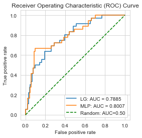

```python
def plot_roc_curve_compare(fpr_dict, tpr_dict):
    for i in fpr.keys():
        plt.plot(
            fpr_dict[i],
            tpr_dict[i],
            label="%s: AUC = %0.4f" % (i, auc(fpr_dict[i], tpr_dict[i])),
        )
    plt.plot([0, 1], [0, 1], color="Green", linestyle="--", label="Random: AUC=0.50")
    plt.xlabel("False positive rate")
    plt.ylabel("True positive rate")
    plt.axis("square")
    plt.title("Receiver Operating Characteristic (ROC) Curve")
    plt.legend(loc="lower right")
    plt.show()


plot_roc_curve_compare(fpr, tpr)
```

#### Solution to Q5

This is an open question. I just mention two directions here.

1. We didn't perform standardization for numeric features, which can perhaps improve the performance of both models
2. We didn't tune parameters of the models in the training. Perhaps, we could at least try a few different parameter settings.